# Further Topics in Statistics and Bioinformatics

Christopher Yau, Justina Zurauskiene

March 1, 2016

# Single cell clustering

In this exercise, you will apply some of the techniques we discussed previously to cluster single cell gene expression data. The aim is to identify potentially novel cell (sub)types by identifying shared gene expression behaviour within subsets of the cells.

During this exercise, you will:

1. Apply clustering techniques to real data sets.
2. Understand some unique properties of single cell data.
3. Investigate how those properties might affect clustering performance.

## Getting started

First, install some R packages that we will make use of in this exercise:

```
  install.packages("devtools")
  devtools::install_github("kieranrcampbell/modelselectionworkshop")
  install.packages("mclust")
  install.packages("mcclust")
  install.packages("gplots")
  install.packages("Rtsne")
```

## Reading data

Read the single cell data from the built-in files:

```r
  library(modelselectionworkshop)
  data(Pollen2014) # loads Pollen2014 et al dataset to object named ‘‘Pollen2014’’
  X <- log2(as.matrix(Pollen2014) + 1) # log transformation of count data
  X <- t(X) # transpose the data matrix so that the observations (cells) are rows
  X[1:4, 1:4] # type this to have a glance at dataset
```

```
##              MTND2P28 MTATP6P1    NOC2L     ISG15
## Cell_2338_1  6.303781 11.00422 1.000000 11.528454
## Cell_2338_10 9.129283 10.93590 6.977280 12.270003
## Cell_2338_11 9.665336 12.26532 6.988685  9.182394
## Cell_2338_12 9.463524 12.10656 0.000000  9.033423
```

```r
  data(CellLibraries) # load the cell type information
  Z <- CellLibraries$TrueLabel_CellLevel # retrieve cell type labels
```

## Visualising data and dimensionality reduction

Lets plot the data as a heatmap for the first 20 genes:

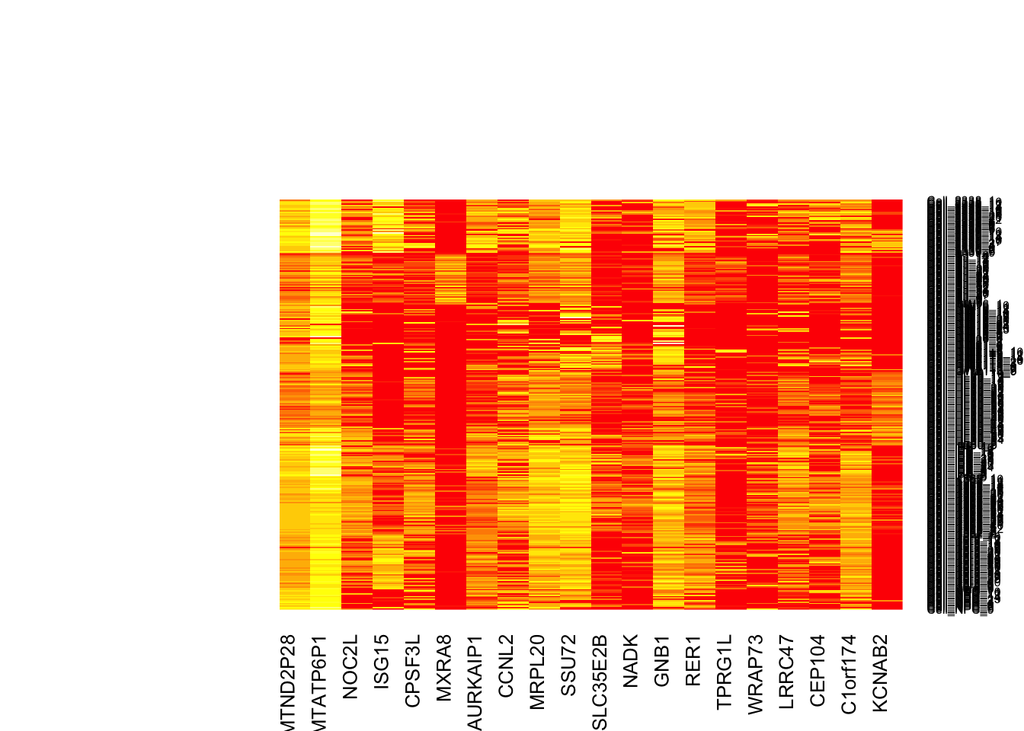

```r
  library(gplots)
  heatmap.2(X[, 1:20],dendrogram='none', Rowv=FALSE, Colv=FALSE,trace='none',key=FALSE)
```

The data is to high-dimensional to be easily visualised. In order to make visualisation (and data modelling) easier, it is customary to apply dimensionality reduction techniques.

You are already familiar with the use of [Principal Components Analysis](https://en.wikipedia.org/wiki/Principal_component_analysis) (PCA). The following code example shows a plot of the single cell expression data in the space spanned by the first two principal components.

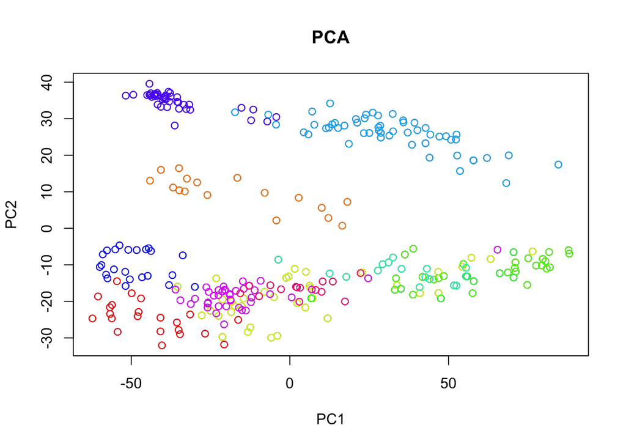

```r
  X_pca <- prcomp(X, center = TRUE, scale.=TRUE) # perform PCA
  cl <- rainbow(11) # create a color map with 11 unique colors
  plot( X_pca$x[, 1], X_pca$x[, 2], main="PCA", xlab="PC1", ylab="PC2")
  for ( i in 1:11 ) {
    loc <- which( Z == i)
    points( X_pca$x[loc, 1], X_pca$x[loc, 2], col=cl[i]) # plot projection of data on to PC1 and PC2
  }
```

PCA is a **linear** dimensionality reduction technique. This means that the principal components are formed by linear combinations of the original input features. In complex data problems, the data may lie on nonlinear manifolds in the feature space. Nonlinear techniques can give greater data modelling flexibility.

[Stochastic Neighbourhood Embedding](https://en.wikipedia.org/wiki/T-distributed_stochastic_neighbor_embedding%20a) (t-SNE) is a popular nonlinear dimensionality technique used in many data visualisation tasks including single cell expression analysis.

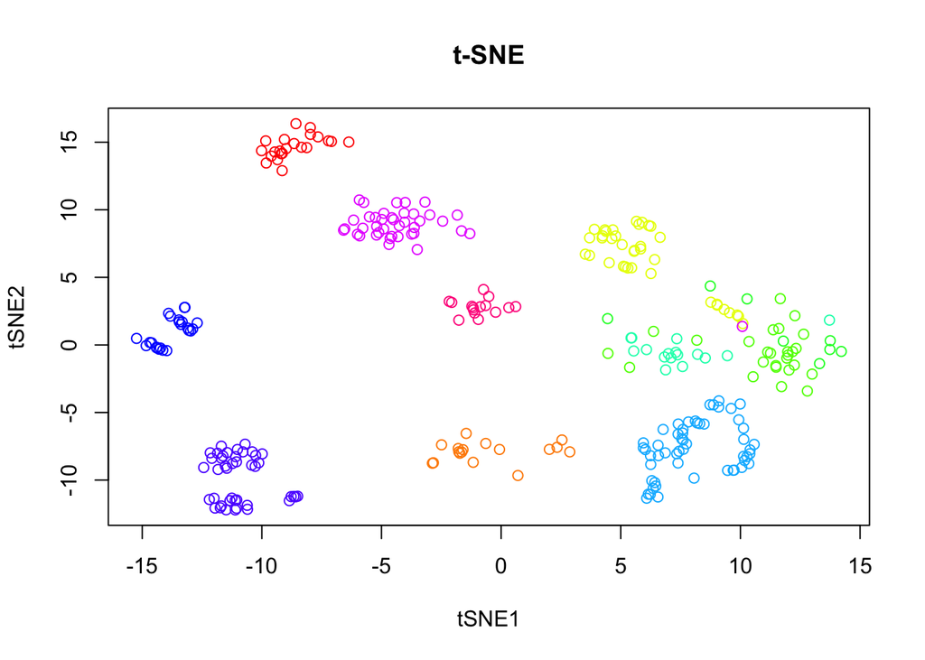

```r
  # load the tsne package
  library(Rtsne)

  # run Rtsne with default parameters
  X_tsne <- Rtsne(X)

  # plot the output of Rtsne
  plot(X_tsne$Y, t='n', main="t-SNE", ylab="tSNE2", xlab="tSNE1")
  for ( i in 1:11 ) {
    loc <- which( Z == i)
    points( X_tsne$Y[loc, 1], X_tsne$Y[loc, 2], col=cl[i]) # plot projection of data on to tsne1 and tsne2
  }
```

## Single cell gene expression profile clustering

The data contains gene expression profiles for 11 cell types which are known.

However, lets pretend we do not know the cell types and see if we can re-discover these using $k$-means clustering.

**EXERCISE**

1. Cluster this single cell data using $k$-means clustering (without any dimensionality reduction), can you recover the true cell type labels?
2. Now pre-process the data using PCA and re-do the clustering. What is the effect on clustering performance? Repeat with t-SNE.

# Zero-inflated gene expression

Now let us plot histograms for the 4 randomly chosen genes across cells:

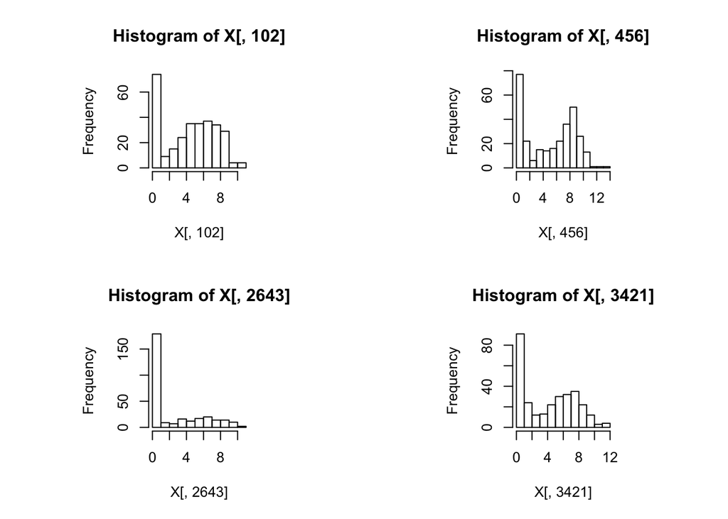

```r
  par(mfrow = c(2, 2), pty = "s")
  hist(X[, 102 ])
  hist(X[, 456 ])
  hist(X[, 2643 ])
  hist(X[, 3421 ])
```

Notice that a large number of cells have zero expression for some genes.

Lets compute the relatioship between the rate at which zeroes occur and the mean level of expression for each gene:

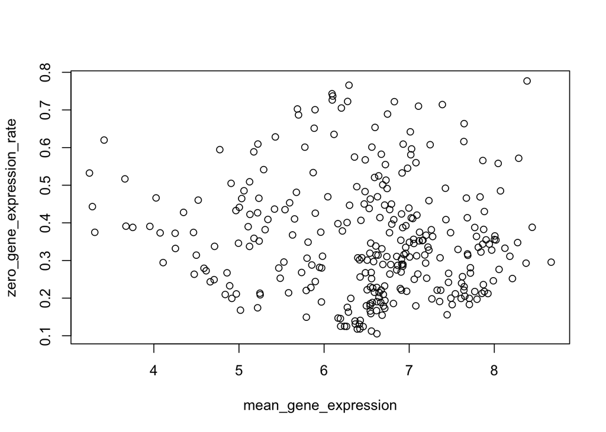

```r
  p <- dim(X)[1] # get number of genes
  n <- dim(X)[2] # get number of cells

  mean_gene_expression <- rep(0, p)
  zero_gene_expression_rate <- rep(0, p)

  for ( i in 1:p ) {

    # find cells which show expression
    nonzero_cells <- which( X[i, ] > 0 )

    # find cells which show no expression
    zero_cells <- which( X[i, ] == 0 )

    zero_gene_expression_rate[i] <- sum( X[i, ] == 0 )/n
    mean_gene_expression[i] <- sum( X[i, nonzero_cells] )/length(nonzero_cells)

  }

  plot( mean_gene_expression, zero_gene_expression_rate )
```

Notice that genes that tend to show low-expression are more likely to have high zero rate.

**EXERCISE**

1. How would zero-inflation affect the performance of clustering algorithms?

Lets write a program to test your thoughts, as before, set up the simulation:

```r
  d <- 10 # simulate ten-dimensional data
  n <- 200 # simulate 200 data points
  K <- 3 # number of classes
  w <- c(0.45, 0.35, 0.2) # frequencies of each class
  m <- matrix( nrow=K, ncol=d ) # class centers (this time we use random numbers to initialise centers)
  m[1, ] =rnorm(d, mean=-2, sd=0.1)
  m[2, ] = rnorm(d, mean=0, sd=0.1)
  m[3, ] = rnorm(d, mean=2, sd=0.1)
  V <- vector("list", K) # class make diagonal covariance matrices
  for ( k in 1:K ) {
    V[[k]] <- diag(d)
  }
```

Now, simulate the data:

```r
  library(MASS) # we need this to use the mvrnorm function
  z <- sample.int(K, n, replace=TRUE, prob=w) # simulate the class assignments
  x <- matrix(nrow=n, ncol=d) # initialise a matrix of zeros to hold simulated data
  for ( i in 1:n ) {
    # get the class assignment for this data point
    k <- z[i]
    # simulate data from a multivariate normal distribution based on the center and covariance matrix for this class
    x[i, ] <- mvrnorm(n = 1, m[k, ], V[[k]])
  }
```

Make a copy of the data and add in random zeros to the copy:

```r
  x_zeros <- x # make a copy of the original data in x
  zero_rate <- 0.1 # parameter specifying the rate of zeros
  rnd <- runif(d*n, min=0, max=1) # generate d*n uniform random numbers between 0 and 1
  less_than_zero_rate <- which( rnd < zero_rate ) # find numbers less than zero_rate parameter
  x_zeros[less_than_zero_rate] = 0
```

Now, compare the original and zeroed versions:

```r
  x[1:5, ]
```

```
##           [,1]      [,2]       [,3]      [,4]       [,5]        [,6]
## [1,] -1.004035 -3.472011 -3.4153699 -2.544373 -3.0990947 -0.42547307
## [2,] -4.373294 -3.269558 -1.1117656 -1.361428 -2.0611142 -1.35315422
## [3,] -1.797939 -1.758739 -3.2714446 -1.554059 -3.6306291 -2.25037417
## [4,]  2.610748  4.074304  2.1700390  2.445100  0.3752319  2.47152254
## [5,]  1.117642 -1.504456  0.1962901  1.045148 -0.3111858 -0.01689663
##            [,7]       [,8]       [,9]      [,10]
## [1,] -1.1297371 -2.3363432 -1.0362843 -2.3337219
## [2,] -2.9794226 -2.5958581 -1.6011557 -2.6521600
## [3,] -3.4300906 -3.5404806 -1.0390818 -2.7110066
## [4,]  0.3524246  4.0024371  2.6961093  1.9499479
## [5,] -0.7987541  0.7532565 -0.2463412 -0.6305281
```

```r
  x_zeros[1:5, ]
```

```
##           [,1]      [,2]       [,3]      [,4]      [,5]        [,6]
## [1,]  0.000000 -3.472011 -3.4153699 -2.544373 -3.099095  0.00000000
## [2,] -4.373294 -3.269558 -1.1117656 -1.361428 -2.061114 -1.35315422
## [3,] -1.797939 -1.758739 -3.2714446 -1.554059 -3.630629 -2.25037417
## [4,]  2.610748  0.000000  2.1700390  2.445100  0.000000  2.47152254
## [5,]  1.117642 -1.504456  0.1962901  1.045148  0.000000 -0.01689663
##            [,7]       [,8]       [,9]      [,10]
## [1,] -1.1297371 -2.3363432 -1.0362843 -2.3337219
## [2,] -2.9794226 -2.5958581  0.0000000 -2.6521600
## [3,] -3.4300906 -3.5404806 -1.0390818 -2.7110066
## [4,]  0.3524246  4.0024371  2.6961093  1.9499479
## [5,] -0.7987541  0.7532565 -0.2463412 -0.6305281
```

Run $k$-means on the two versions of the data:

```r
  kc <- kmeans(x, K) # run k-means
  kc_zeros <- kmeans(x_zeros, K) # run k-means
```

Compare the clusterings:

```r
  library(mcclust)
  arandi(z, kc$cluster)
```

```
## [1] 0.4675861
```

```r
  arandi(z, kc_zeros$cluster)
```

```
## [1] 1
```

This is for only one zero rate and one sampled data, we would like to see average performance over many replicates and zero rates. So lets loop!

```r
  reps <- 100
  zero_rate_used <- rep(0, reps)
  e <- rep(0, reps)

  for ( it in 1 : reps ) {

    zero_rate <- runif(1, 0, 1) # parameter specifying the rate of zeros

    z <- sample.int(K, n, replace=TRUE, prob=w) # simulate the class assignments
    x <- matrix(nrow=n, ncol=d) # initialise a matrix of zeros to hold simulated data
    for ( i in 1:n ) {
      # get the class assignment for this data point
      k <- z[i]
      # simulate data from a multivariate normal distribution based on the center and covariance matrix for this class
      x[i, ] <- mvrnorm(n = 1, m[k, ], V[[k]])
    }

    x_zeros <- x # make a copy of the original data in x
    rnd <- runif(d*n, min=0, max=1) # generate d*n uniform random numbers between 0 and 1
    less_than_zero_rate <- which( rnd < zero_rate ) # find numbers less than zero_rate parameter
    x_zeros[less_than_zero_rate] = 0

    kc <- kmeans(x, K) # run k-means
    kc_zeros <- kmeans(x_zeros, K) # run k-means

    zero_rate_used[it] <- zero_rate
    e[it] = arandi(z, kc$cluster) - arandi(z, kc_zeros$cluster) # store the difference between the adjusted rand indices
  }
```

Now, lets plot the differences in adjusted rand indices as a function of the zero rate:

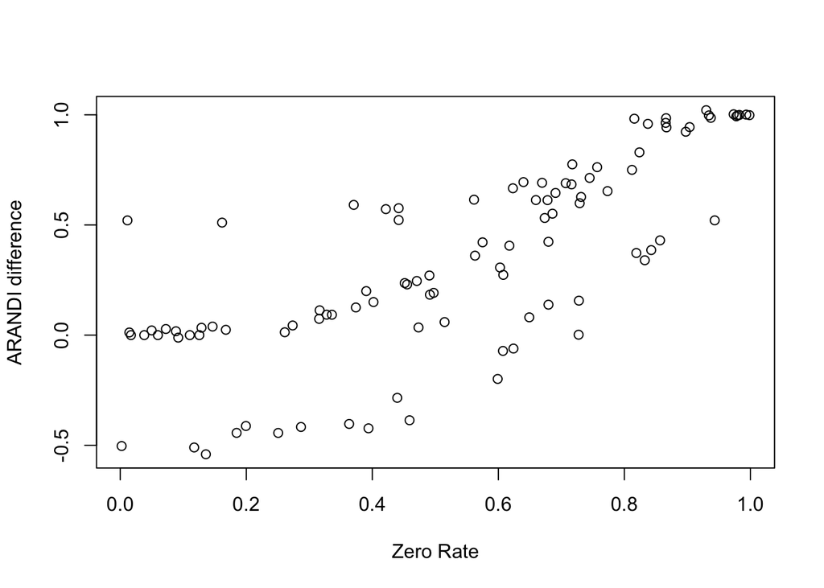

```r
  plot(zero_rate_used, e, xlab="Zero Rate", ylab="ARANDI difference")
```

We can conclude that as the rate of zeroes increases, the performance of $k$-means clustering diminishes.

**EXERCISE**

1. How can we modify the simulation to account for this observation?
2. Implement this modified simulation and see what the effect on clustering performance is.